# Resources

2022-06-17

## The Plan

| Time | June 13 | June 14 | June 15-16 | June 17 |
| --- | --- | --- | --- | --- |
| 9:00 | **Intro: Reproducibility - why bother?** | *Debug any software issues* | *Work on CJE articles* | **Abel Brodeur: i4replication** |
| 10:00 | **Reproducible practice: What you can do!** | **Toolkit: Online computing platforms: WholeTale, CodeOcean** |  | **Abel Brodeur: SSRP** |
| 11:00 | **What will you be doing in the Summer School** | **Capturing system and errors** |  | **Next steps** |
| 12:00 | Lunch Break | Lunch Break |  |  |
| 13:00 | **Toolkit: Command line/Git/Markdown** | **Discuss and finish test article of the day** |  |  |
| 14:00 | **Data provenance, data citations: where did they get this?** | Work on first test article |  |  |
| 15:00 | **How to write a replication report: empathy and humility** |  |  |  |
| 16:00 | **Start on first test article** | **The CJE Papers: How reproducible are they?** |  |  |

## Some resources

## Example solution for the test case

REPLICATION.pdf

## A template report

This report serves as a starting point for a reproducibility check.

- [Template Report repository](https://github.com/AEADataEditor/replication-template/blob/master/REPLICATION.md)
  - [the actual Template Report used by AEA](https://github.com/AEADataEditor/replication-template/blob/master/REPLICATION.md)
  - [the template-config.do](https://github.com/AEADataEditor/replication-template/blob/11d1ae2a2db7c5a61ac4e8dcb4fecd1b47d543ec/template-config.do#L64) - you may need to adjust the `$rootdir` in your Stata code. This code should be inserted into any “main” file, or the entire “template-config.do” downloaded and included with the code “`include "config.do"`”

## Creating a (Whole)Tale from a Scholarsportal (Dataverse) entry

- Use this form and simply paste the “`doi:10.1111/caje.22222`” part.

## List of articles

The list of CJE articles that are eligible for reproducibility checks and replication enhancements is

[this Google Sheet](https://docs.google.com/spreadsheets/d/1ahZc4jsNSfApMHHkjp7TTh0jFdZG3LTZTIWllU4E4UA/edit#gid=0)

If you cannot see the spreadsheet, please request access.

## Uploading reports

Upload your finished reports (whenever that happens) to the link provided on the “[Upload tab](https://docs.google.com/spreadsheets/d/1ahZc4jsNSfApMHHkjp7TTh0jFdZG3LTZTIWllU4E4UA/edit#gid=438016711)” of the above Spreadsheet (the form is not public, to avoid spam).

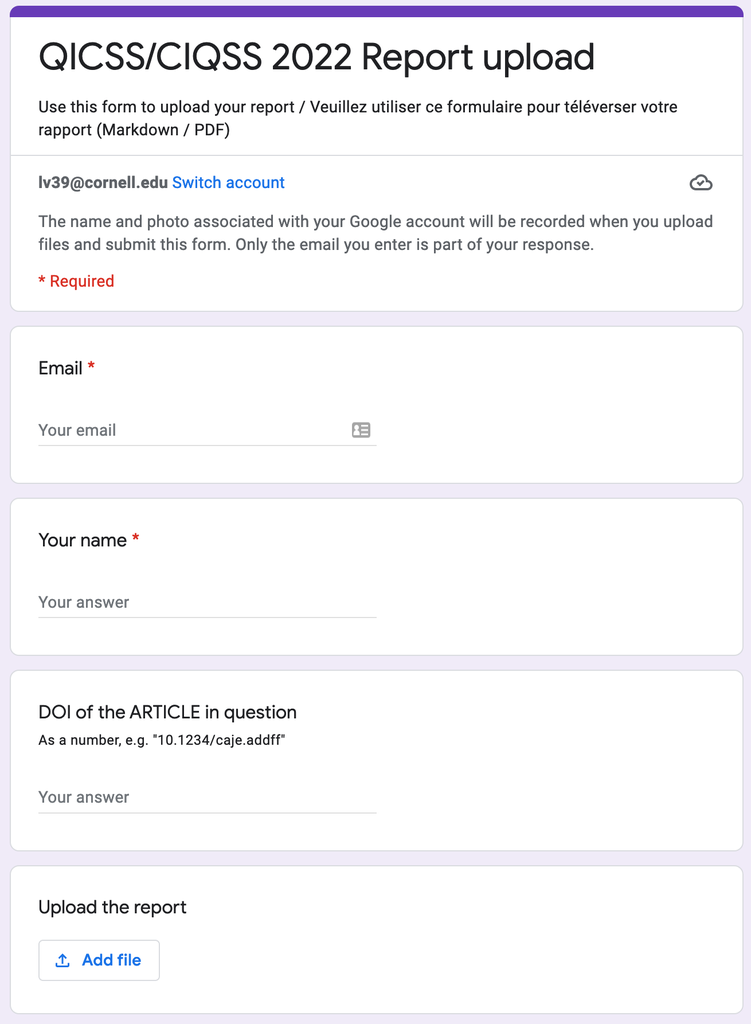

Upload image

You’ll be asked for email, name, and the DOI of the manuscript/ARTICLE, e.g. only the numeric part (same as in Column A of the spreadsheet): “10.1111/caje.12559”, then upload the report (in Markdown or PDF format).

## Creating your own replication package

- [Template README](https://social-science-data-editors.github.io/template_README/)

## Replication Challenge

- Abel Brodeur’s presentation
  - [Fernando Hoces de la Guardia’s slides, referenced](https://bitss.github.io/acre-slides-ctree2022/)
- [Template Replication article](https://osf.io/8dkxc/) by Abel Brodeur